# Making a SageMaker image-classifier microservice

### Results:

- The worst recall breed class is Eskimo Dog, which is most often confused with Malamute and Siberian Husky. The images for these three breeds are very similar in appearance, and in fact comparing images at Eskimo Dog websites to the train/test images, it's clear that most of the dogs tagged as "Eskimo Dog" are in fact Huskies or Malamutes. So, this is appears to be a case of mislabelling.
- The next low recall breed is Walker Hound, which is confused mostly with English Foxhound and occasionally with Basset. In this case, the two breeds just look very similar. www.coonhoundscompanions.com writes:

  > "It’s pretty hard to tell the difference between Treeing Walker coonhounds and foxhounds. Most of the differences are behavioral rather than visibly structural, and the behavioral differences are most evident in a hunting setting."
- Collies are confused with close relatives Border Collies and Shetland Sheepdogs.
- Miniature Poodles are confused with Toy and Standard Poodles. Here is a case of one breed being separated by size, which confuses the classifier since it doesn't know about size.
- Lhasas are confused with Maltese Dogs and Shihs, which look very similar comparing images.

```python
# number of low recall classes to analyze
nworst = 5
# number of highest count classes for each low recall class to collect.
# note: the highest count class will probably be the class itself.
nclosest = 3

worst = idx[:nworst]

# collect list of worst recall IDs and the ids of breeds the classifier
#  confused them with
idsets = []
idnames = []
for i in worst:
    # exclude ids that already exist in prev set,
    #  so like groupings will only be shown once.
    if not idsets or i not in idsets[-1]:
        # collect id for this class plus classes confused w/ it
        idset = [i]
        idset.extend(np.argsort(-cm_count.iloc[i,:])[:nclosest])
        # use pandas to remove dupes w/out sorting
        idsets.append(pd.Series(idset).unique()[:nclosest])
        idnames.append(classnames[idsets[-1]])
```

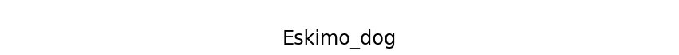

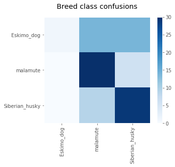

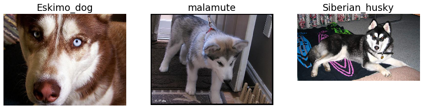

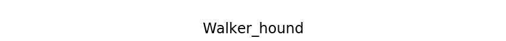

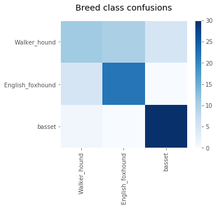

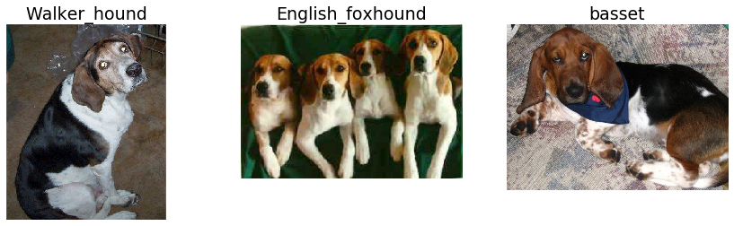

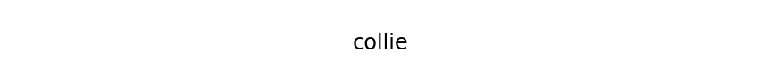

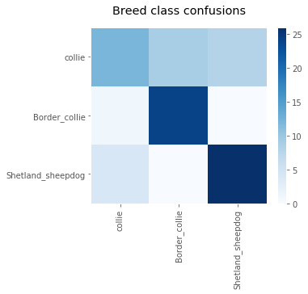

[figure not shown]

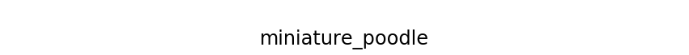

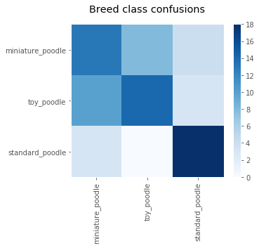

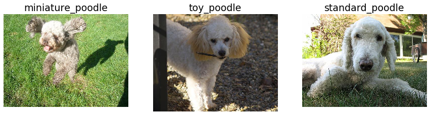

[3 more figures not shown]

```python
import matplotlib.image as mpimg

def plot_image(imgpath):
    """read image file and display it in the current figure"""
    img = mpimg.imread(imgpath)
    imgplot = plt.imshow(img)
    plt.axis('off')
    plt.grid(b=None)

# show details about classes w/ the lowest recall
for ids, names in zip(idsets,idnames):
    # create offset breed name title
    plt.figure(figsize=(15, 1));
    plt.axis('off')
    plt.grid(b=None)
    plt.title(names[0], fontsize=24, y=-0.01)

    # draw a confusion mx for just these breeds
    wcm = cm_count.iloc[ids,ids]
    # set cols to breed names for figure tick labels
    wcm.columns = names
    plt.figure(figsize=(6, 4))
    plot_similarity_mx_df(wcm, title='Breed class confusions', plot_colorbar=True)

    # show example images of the breeds
    plt.figure(figsize=(15, 4))
    for i, bid, name in zip(range(len(ids)),ids,names):
        plt.subplot(1,len(ids),i+1)
        plot_image(rootdir+df.path[df.classid==bid].values[11])
        plt.title(name,fontsize=19)
        plt.gca().set_anchor('N');
```